# Heat-Related Mortality and Lifespan Inequality

# 9. Baseline Mortality Data

To construct life tables, we need **baseline mortality rates** by age and year. These represent the expected mortality in the absence of climate change impacts.

## 9.1 Load Eurostat Mortality Projections

```r
# Eurostat mortality projections for Austria
# Data source: Eurostat demo_mprojmorr (EUROPOP2023)
#
# If you don't have this file, you can download it from:
# https://ec.europa.eu/eurostat/databrowser/view/demo_mprojmorr/

# For this demo, we'll load pre-processed data
mort_proj_path <- "../data/mortality_projections_austria.csv"

if (!file.exists(mort_proj_path)) {
  cat("Warning: Baseline mortality file not found.\n")
  cat("Please download Eurostat EUROPOP2023 projections.\n")
  cat("Using synthetic data for demonstration...\n")

  # Create synthetic baseline mortality (Gompertz model)
  # mx = a * exp(b * age)
  # Typical values for high-income countries
  ages_synth <- 20:100
  years_synth <- 2015:2100

  mort_proj <- CJ(age = ages_synth, year = years_synth)

  # Gompertz parameters (calibrated to approximate Austria)
  a <- 0.0001
  b <- 0.08

  # Add slight mortality improvement over time (1% per decade)
  mort_proj[, mx := a * exp(b * age) * (0.99 ^ ((year - 2015) / 10))]

} else {
  mort_proj <- fread(mort_proj_path)

  # Filter to relevant ages and years
  mort_proj <- mort_proj[age >= 20 & age <= 100]
  mort_proj <- mort_proj[year >= 2015 & year <= 2100]
}
# Ensure proper ordering
setkey(mort_proj, year, age)

cat(sprintf("Baseline mortality data:\n"))
```

```
## Baseline mortality data:
```

```r
cat(sprintf("  Ages: %d–%d\n", min(mort_proj$age), max(mort_proj$age)))
```

```
##   Ages: 20–100
```

```r
cat(sprintf("  Years: %d–%d\n", min(mort_proj$year), max(mort_proj$year)))
```

```
##   Years: 2015–2100
```

```r
cat(sprintf("  Records: %s\n", format(nrow(mort_proj), big.mark = ",")))
```

```
##   Records: 6,966
```

```r
head(mort_proj, 10)
```

```
## Key: <year, age>
##       age  year           mx
##     <int> <int>        <num>
##  1:    20  2015 0.0004953032
##  2:    21  2015 0.0005365556
##  3:    22  2015 0.0005812437
##  4:    23  2015 0.0006296538
##  5:    24  2015 0.0006820958
##  6:    25  2015 0.0007389056
##  7:    26  2015 0.0008004469
##  8:    27  2015 0.0008671138
##  9:    28  2015 0.0009393331
## 10:    29  2015 0.0010175674
```

**Data structure**: - `age`: Single-year ages (20–100) - `year`: Calendar year (2015–2100) - `mx`: Central death rate (annual probability of death)

**Interpretation**: `mx = 0.001` means 1 death per 1,000 person-years (0.1% annual mortality)

## 9.2 Baseline Mortality Summary

```r
# Sample mortality rates for selected ages and years
sample_years <- c(2020, 2050, 2080)
sample_ages <- c(30, 50, 70, 90)

mort_sample <- mort_proj[year %in% sample_years & age %in% sample_ages]
mort_wide <- dcast(mort_sample, age ~ year, value.var = "mx")

cat("\n=== Baseline Mortality Rates (mx) ===\n")
```

```
##
## === Baseline Mortality Rates (mx) ===
```

```r
print(mort_wide)
```

```
## Key: <age>
##      age        2020        2050        2080
##    <int>       <num>       <num>       <num>
## 1:    30 0.001096792 0.001064216 0.001032608
## 2:    50 0.005432447 0.005271098 0.005114541
## 3:    70 0.026907088 0.026107920 0.025332489
## 4:    90 0.133271678 0.129313376 0.125472640
```

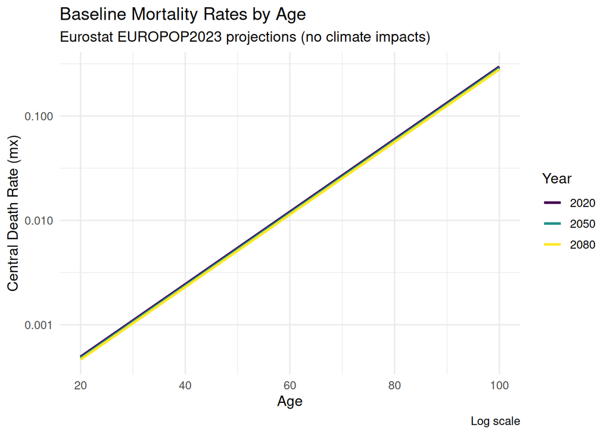

```r
# Visualize baseline mortality by age (for selected years)
library(ggplot2)

ggplot(mort_proj[year %in% sample_years], aes(x = age, y = mx, color = factor(year))) +
  geom_line(linewidth = 1) +
  scale_y_log10(labels = scales::label_comma()) +
  scale_color_viridis_d(name = "Year") +
  labs(
    title = "Baseline Mortality Rates by Age",
    subtitle = "Eurostat EUROPOP2023 projections (no climate impacts)",
    x = "Age",
    y = "Central Death Rate (mx)",
    caption = "Log scale"
  ) +
  theme_minimal(base_size = 12)
```

# 10. Apply Climate Multipliers to Baseline Mortality

To obtain **climate-adjusted mortality**:

$$mx_{\text{climate}}(a, y) = mx_{\text{baseline}}(a, y) \times M(a, y)$$

where $M(a, y) > 1$ indicates increased mortality due to climate change.

## 10.1 Merge Multipliers with Baseline Mortality

```r
# Use ensemble mean multiplier (already averaged across GCMs)
mult_subset <- multipliers[, .(age, year, multiplier = multiplier_mean)]

# Merge with baseline mortality
mort_climate <- merge(
  mort_proj,
  mult_subset,
  by = c("age", "year"),
  all.x = TRUE
)

# For years/ages without multipliers, assume no climate impact
mort_climate[is.na(multiplier), multiplier := 1.0]

# Compute climate-adjusted mortality
mort_climate[, mx_climate := mx * multiplier]

cat(sprintf("Climate-adjusted mortality computed for %s records\n",
            format(nrow(mort_climate), big.mark = ",")))
```

```
## Climate-adjusted mortality computed for 6,966 records
```

```r
head(mort_climate, 15)
```

```
## Key: <age, year>
##       age  year           mx multiplier   mx_climate
##     <int> <int>        <num>      <num>        <num>
##  1:    20  2015 0.0004953032  0.9985854 0.0004946026
##  2:    20  2016 0.0004948057  0.9988842 0.0004942536
##  3:    20  2017 0.0004943086  1.0001271 0.0004943715
##  4:    20  2018 0.0004938121  0.9999122 0.0004937687
##  5:    20  2019 0.0004933161  0.9999351 0.0004932840
##  6:    20  2020 0.0004928205  0.9990347 0.0004923448
##  7:    20  2021 0.0004923255  0.9987839 0.0004917267
##  8:    20  2022 0.0004918309  0.9993929 0.0004915323
##  9:    20  2023 0.0004913368  0.9985092 0.0004906044
## 10:    20  2024 0.0004908433  0.9998502 0.0004907698
## 11:    20  2025 0.0004903502  1.0003672 0.0004905303
## 12:    20  2026 0.0004898576  1.0011450 0.0004904185
## 13:    20  2027 0.0004893656  1.0002723 0.0004894988
## 14:    20  2028 0.0004888740  1.0003994 0.0004890693
## 15:    20  2029 0.0004883829  1.0014309 0.0004890817
```

## 10.2 Comparison: Baseline vs Climate Mortality

```r
# Summary statistics
comparison <- mort_climate[year >= 2050, .(
  mean_mx_base    = mean(mx),
  mean_mx_climate = mean(mx_climate),
  mean_multiplier = mean(multiplier),
  max_multiplier  = max(multiplier)
), by = year]

cat("\n=== Mortality Comparison: Baseline vs Climate (2050+) ===\n")
```

```
##
## === Mortality Comparison: Baseline vs Climate (2050+) ===
```

```r
print(comparison[year %in% c(2050, 2070, 2090, 2099)])
```

```
##     year mean_mx_base mean_mx_climate mean_multiplier max_multiplier
##    <int>        <num>           <num>           <num>          <num>
## 1:  2050   0.04614168      0.04691979       1.0027207       1.022613
## 2:  2070   0.04522346      0.04594989       1.0036691       1.021155
## 3:  2090   0.04432351      0.04445806       0.9947973       1.006807
## 4:  2099   0.04392440      0.04394905       0.9934119       1.003951
```

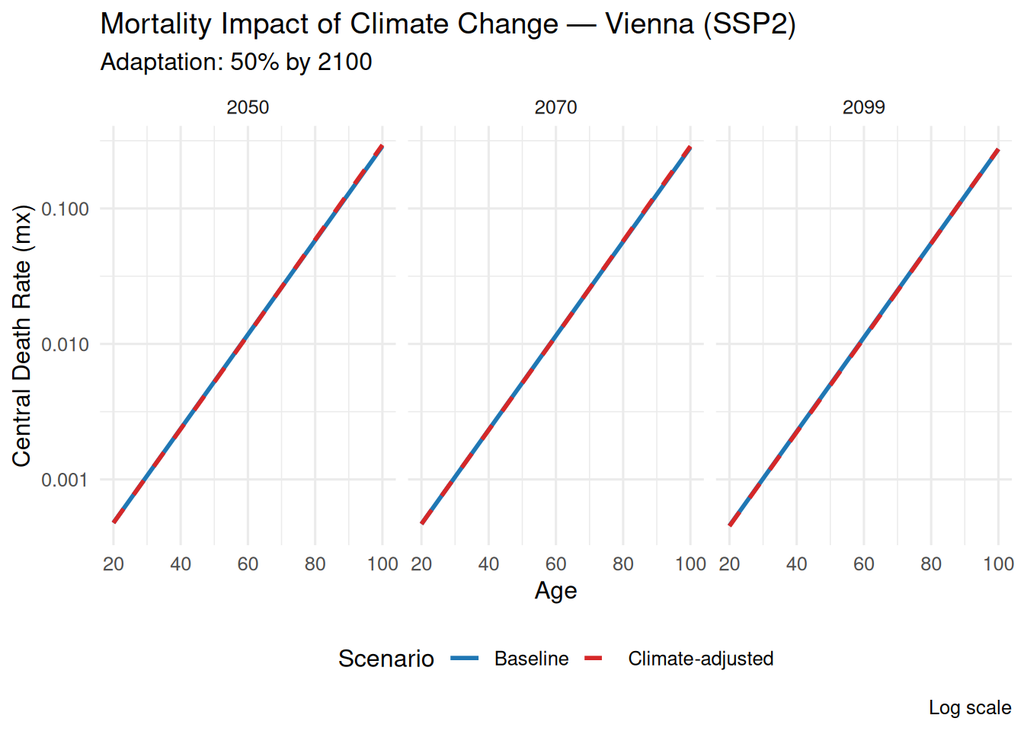

```r
# Visualize the impact
ggplot(mort_climate[year %in% c(2050, 2070, 2099)],
       aes(x = age)) +
  geom_line(aes(y = mx, color = "Baseline"), linewidth = 1) +
  geom_line(aes(y = mx_climate, color = "Climate-adjusted"),
            linewidth = 1, linetype = "dashed") +
  facet_wrap(~ year, ncol = 3) +
  scale_y_log10(labels = scales::label_comma()) +
  scale_color_manual(
    name = "Scenario",
    values = c("Baseline" = "#1f77b4", "Climate-adjusted" = "#d62728")
  ) +
  labs(
    title = sprintf("Mortality Impact of Climate Change — %s (SSP%d)", city, scenario),
    subtitle = sprintf("Adaptation: %.0f%% by 2100", adaptation_level * 100),
    x = "Age",
    y = "Central Death Rate (mx)",
    caption = "Log scale"
  ) +
  theme_minimal(base_size = 12) +
  theme(legend.position = "bottom")
```

# 11. Cohort Life Table Construction

A **cohort life table** tracks a hypothetical birth cohort through time, applying age-specific mortality rates for each calendar year they live through.

For a cohort born in year $Y_0$: - At age 20 (year $Y_0 + 20$), use mortality for year $Y_0 + 20$, age 20 - At age 21 (year $Y_0 + 21$), use mortality for year $Y_0 + 21$, age 21 - … and so on until the cohort dies out

This differs from a **period life table**, which uses mortality rates from a single year.

## 11.1 Define Cohort Parameters

```r
cohort_birth_year <- 2020  # Birth year of cohort
cohort_start_age  <- 20    # Start tracking at age 20 (year 2040)
radix             <- 100000  # Initial cohort size (lx at start age)

cat(sprintf("Cohort Parameters:\n"))
```

```
## Cohort Parameters:
```

```r
cat(sprintf("  Birth year: %d\n", cohort_birth_year))
```

```
##   Birth year: 2020
```

```r
cat(sprintf("  Start tracking at age %d (year %d)\n",
            cohort_start_age, cohort_birth_year + cohort_start_age))
```

```
##   Start tracking at age 20 (year 2040)
```

```r
cat(sprintf("  Initial cohort size (radix): %s\n", format(radix, big.mark = ",")))
```

```
##   Initial cohort size (radix): 1e+05
```

## 11.2 Build Cohort Life Table Function

```r
build_cohort_lifetable <- function(mort_data, birth_year, start_age, radix = 100000) {
  # Filter to cohort's age-year trajectory
  # For someone born in 'birth_year', at age 'a' they are in year 'birth_year + a'

  mort_data <- copy(mort_data)
  mort_data[, cohort_year := year - age]

  cohort_data <- mort_data[cohort_year == birth_year & age >= start_age]
  setorder(cohort_data, age)

  if (nrow(cohort_data) == 0) {
    stop("No data found for this cohort")
  }

  # Build life table columns
  n <- nrow(cohort_data)

  # Convert central death rate (mx) to probability of death (qx)
  # Standard approximation: qx ≈ mx / (1 + 0.5 * mx)
  # For small mx, qx ≈ 1 - exp(-mx) is also valid
  cohort_data[, qx_base := mx / (1 + 0.5 * mx)]
  cohort_data[, qx_climate := mx_climate / (1 + 0.5 * mx_climate)]

  # Ensure qx does not exceed 1
  cohort_data[qx_base > 1, qx_base := 1]
  cohort_data[qx_climate > 1, qx_climate := 1]

  # Initialize survivors
  cohort_data[, lx_base := as.numeric(NA)]
  cohort_data[, lx_climate := as.numeric(NA)]

  cohort_data[1, lx_base := radix]
  cohort_data[1, lx_climate := radix]

  # Iteratively compute survivors and deaths
  for (i in 1:n) {
    if (i < n) {
      # Baseline
      cohort_data[i, dx_base := lx_base * qx_base]
      cohort_data[i + 1, lx_base := cohort_data[i, lx_base - dx_base]]

      # Climate
      cohort_data[i, dx_climate := lx_climate * qx_climate]
      cohort_data[i + 1, lx_climate := cohort_data[i, lx_climate - dx_climate]]
    } else {
      # Last age: all remaining die
      cohort_data[i, dx_base := lx_base]
      cohort_data[i, dx_climate := lx_climate]
    }
  }

  # Person-years lived (Lx): approximation using average of lx and lx+1
  cohort_data[, Lx_base := (lx_base + c(lx_base[-1], 0)) / 2]
  cohort_data[, Lx_climate := (lx_climate + c(lx_climate[-1], 0)) / 2]

  # For last age, use lx / mx (if mx > 0)
  cohort_data[n, Lx_base := ifelse(mx > 0, lx_base / mx, lx_base)]
  cohort_data[n, Lx_climate := ifelse(mx_climate > 0, lx_climate / mx_climate, lx_climate)]

  # Total person-years from age x onwards (Tx)
  cohort_data[, Tx_base := rev(cumsum(rev(Lx_base)))]
  cohort_data[, Tx_climate := rev(cumsum(rev(Lx_climate)))]

  # Life expectancy at age x (ex)
  cohort_data[, ex_base := Tx_base / lx_base]
  cohort_data[, ex_climate := Tx_climate / lx_climate]

  return(cohort_data)
}
```

## 11.3 Construct Baseline and Climate Life Tables

```r
lifetable <- build_cohort_lifetable(
  mort_climate,
  birth_year = cohort_birth_year,
  start_age = cohort_start_age,
  radix = radix
)

cat(sprintf("Cohort life table constructed:\n"))
```

```
## Cohort life table constructed:
```

```r
cat(sprintf("  Ages: %d–%d\n", min(lifetable$age), max(lifetable$age)))
```

```
##   Ages: 20–80
```

```r
cat(sprintf("  Years: %d–%d\n", min(lifetable$year), max(lifetable$year)))
```

```
##   Years: 2040–2100
```

```r
# Display key columns
lifetable_display <- lifetable[, .(
  age, year,
  mx_base = round(mx, 6),
  mx_climate = round(mx_climate, 6),
  multiplier = round(multiplier, 3),
  qx_base = round(qx_base, 5),
  qx_climate = round(qx_climate, 5),
  lx_base = round(lx_base, 0),
  lx_climate = round(lx_climate, 0),
  ex_base = round(ex_base, 2),
  ex_climate = round(ex_climate, 2)
)]

cat("\nLife Table (first 20 rows):\n")
```

```
##
## Life Table (first 20 rows):
```

```r
print(head(lifetable_display, 20))
```

```
## Key: <age, year>
##       age  year  mx_base mx_climate multiplier qx_base qx_climate lx_base
##     <int> <int>    <num>      <num>      <num>   <num>      <num>   <num>
##  1:    20  2040 0.000483   0.000483      1.001 0.00048    0.00048  100000
##  2:    21  2041 0.000523   0.000523      1.000 0.00052    0.00052   99952
##  3:    22  2042 0.000566   0.000566      1.001 0.00057    0.00057   99899
##  4:    23  2043 0.000612   0.000612      1.000 0.00061    0.00061   99843
##  5:    24  2044 0.000663   0.000663      1.000 0.00066    0.00066   99782
##  6:    25  2045 0.000717   0.000716      0.999 0.00072    0.00072   99716
##  7:    26  2046 0.000776   0.000776      1.000 0.00078    0.00078   99644
##  8:    27  2047 0.000840   0.000840      1.000 0.00084    0.00084   99567
##  9:    28  2048 0.000909   0.000908      0.999 0.00091    0.00091   99483
## 10:    29  2049 0.000983   0.000983      1.000 0.00098    0.00098   99393
## 11:    30  2050 0.001064   0.001062      0.998 0.00106    0.00106   99295
## 12:    31  2051 0.001152   0.001150      0.999 0.00115    0.00115   99190
```

[output cut: 34 more lines]

```r
cat("\nLife Table (last 10 rows):\n")
```

```
##
## Life Table (last 10 rows):
```

```r
print(tail(lifetable_display, 10))
```

```
## Key: <age, year>
##       age  year  mx_base mx_climate multiplier qx_base qx_climate lx_base
##     <int> <int>    <num>      <num>      <num>   <num>      <num>   <num>
##  1:    71  2091 0.027141   0.027023      0.996 0.02678    0.02666   72302
##  2:    72  2092 0.029372   0.029162      0.993 0.02895    0.02874   70366
##  3:    73  2093 0.031786   0.031572      0.993 0.03129    0.03108   68329
##  4:    74  2094 0.034399   0.034225      0.995 0.03382    0.03365   66192
##  5:    75  2095 0.037226   0.037118      0.997 0.03655    0.03644   63953
##  6:    76  2096 0.040286   0.040033      0.994 0.03949    0.03925   61616
##  7:    77  2097 0.043598   0.043310      0.993 0.04267    0.04239   59183
##  8:    78  2098 0.047181   0.046971      0.996 0.04609    0.04589   56657
##  9:    79  2099 0.051060   0.050876      0.996 0.04979    0.04961   54046
## 10:    80  2100 0.055257   0.055257      1.000 0.05377    0.05377   51355
##     lx_climate ex_base ex_climate
##          <num>   <num>      <num>
##  1:      72477   20.63      20.66
##  2:      70544   20.18      20.21
##  3:      68517   19.77      19.79
##  4:      66387   19.39      19.41
##  5:      64153   19.05      19.07
##  6:      61815   18.76      18.77
##  7:      59389   18.51      18.52
##  8:      56872   18.31      18.32
##  9:      54262   18.17      18.17
## 10:      51569   18.10      18.10
```

# 12. Life Expectancy Analysis

## 12.1 Life Expectancy at Age 20

```r
e20_base <- lifetable[age == cohort_start_age, ex_base]
e20_climate <- lifetable[age == cohort_start_age, ex_climate]

delta_e20 <- e20_climate - e20_base
pct_delta_e20 <- (delta_e20 / e20_base) * 100

cat(sprintf("\n=== Life Expectancy at Age %d ===\n", cohort_start_age))
```

```
##
## === Life Expectancy at Age 20 ===
```

```r
cat(sprintf("  Baseline (no climate impact):   %.2f years\n", e20_base))
```

```
##   Baseline (no climate impact):   62.41 years
```

```r
cat(sprintf("  Climate-adjusted (SSP%d):        %.2f years\n", scenario, e20_climate))
```

```
##   Climate-adjusted (SSP2):        62.49 years
```

```r
cat(sprintf("  Difference:                     %.2f years (%.2f%%)\n",
            delta_e20, pct_delta_e20))
```

```
##   Difference:                     0.08 years (0.12%)
```

```r
if (delta_e20 < 0) {
  cat(sprintf("\n  → Climate change reduces life expectancy by %.1f months\n",
              abs(delta_e20) * 12))
} else {
  cat(sprintf("\n  → Climate change increases life expectancy by %.1f months\n",
              delta_e20 * 12))
  cat("     (Note: This may occur if cold-related mortality reduction exceeds heat increase)\n")
}
```

```
##
##   → Climate change increases life expectancy by 0.9 months
##      (Note: This may occur if cold-related mortality reduction exceeds heat increase)
```

## 12.2 Life Expectancy by Age

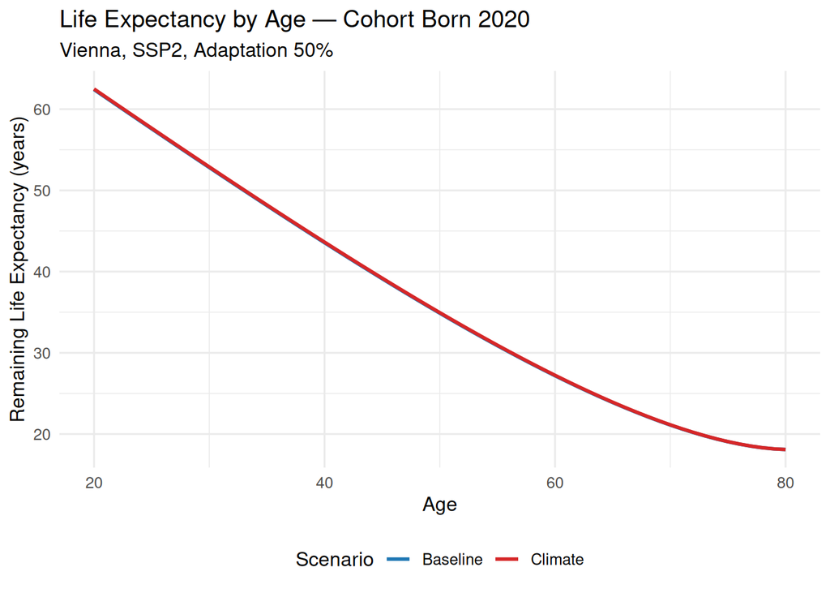

```r
# Plot life expectancy across ages
ex_data <- lifetable[, .(
  age,
  Baseline = ex_base,
  Climate = ex_climate
)]

ex_long <- melt(ex_data, id.vars = "age",
                variable.name = "Scenario", value.name = "ex")

ggplot(ex_long, aes(x = age, y = ex, color = Scenario)) +
  geom_line(linewidth = 1) +
  scale_color_manual(
    values = c("Baseline" = "#1f77b4", "Climate" = "#d62728")
  ) +
  labs(
    title = sprintf("Life Expectancy by Age — Cohort Born %d", cohort_birth_year),
    subtitle = sprintf("%s, SSP%d, Adaptation %.0f%%", city, scenario, adaptation_level * 100),
    x = "Age",
    y = "Remaining Life Expectancy (years)"
  ) +
  theme_minimal(base_size = 12) +
  theme(legend.position = "bottom")
```

## 12.3 Survivorship Curves

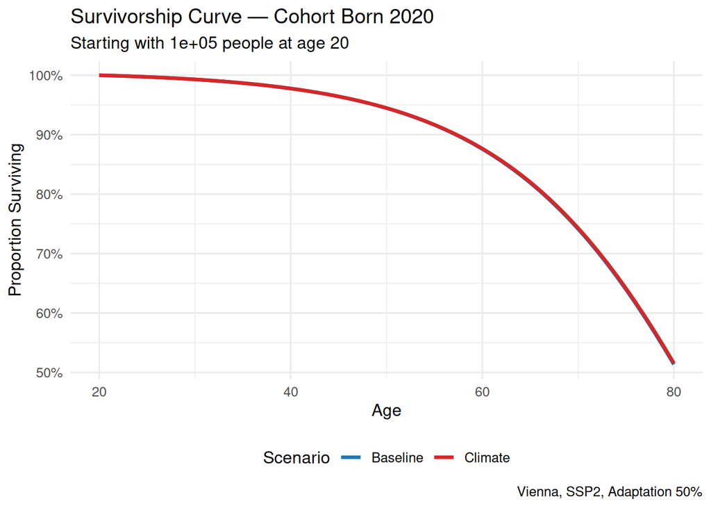

```r
surv_data <- lifetable[, .(
  age,
  Baseline = lx_base,
  Climate = lx_climate
)]

surv_long <- melt(surv_data, id.vars = "age",
                  variable.name = "Scenario", value.name = "lx")

ggplot(surv_long, aes(x = age, y = lx / radix, color = Scenario)) +
  geom_line(linewidth = 1.2) +
  scale_y_continuous(labels = scales::percent_format()) +
  scale_color_manual(
    values = c("Baseline" = "#1f77b4", "Climate" = "#d62728")
  ) +
  labs(
    title = sprintf("Survivorship Curve — Cohort Born %d", cohort_birth_year),
    subtitle = sprintf("Starting with %s people at age %d",
                       format(radix, big.mark = ","), cohort_start_age),
    x = "Age",
    y = "Proportion Surviving",
    caption = sprintf("%s, SSP%d, Adaptation %.0f%%",
                      city, scenario, adaptation_level * 100)
  ) +
  theme_minimal(base_size = 12) +
  theme(legend.position = "bottom")
```

## 12.4 Cumulative Deaths

```r
# Calculate cumulative deaths by age
lifetable[, cumul_deaths_base := cumsum(dx_base)]
lifetable[, cumul_deaths_climate := cumsum(dx_climate)]
lifetable[, excess_deaths := cumul_deaths_climate - cumul_deaths_base]

# Total excess deaths over lifetime
total_excess <- lifetable[age == max(age), excess_deaths]
pct_excess <- (total_excess / radix) * 100

cat(sprintf("\n=== Cumulative Excess Deaths ===\n"))
```

```
##
## === Cumulative Excess Deaths ===
```

```r
cat(sprintf("  Initial cohort size: %s\n", format(radix, big.mark = ",")))
```

```
##   Initial cohort size: 1e+05
```

```r
cat(sprintf("  Total excess deaths: %.0f (%.2f%% of cohort)\n",
            total_excess, pct_excess))
```

```
##   Total excess deaths: 0 (0.00% of cohort)
```

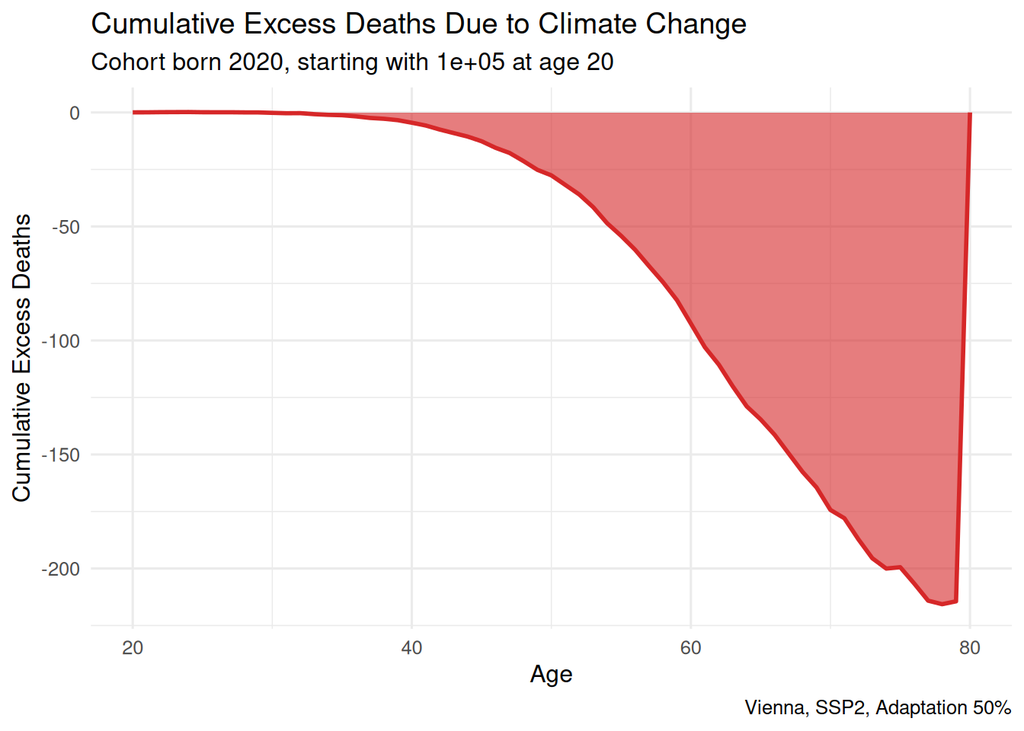

```r
# Plot excess deaths over age
ggplot(lifetable, aes(x = age, y = excess_deaths)) +
  geom_area(fill = "#d62728", alpha = 0.6) +
  geom_line(color = "#d62728", linewidth = 1) +
  scale_y_continuous(labels = scales::comma_format()) +
  labs(
    title = "Cumulative Excess Deaths Due to Climate Change",
    subtitle = sprintf("Cohort born %d, starting with %s at age %d",
                       cohort_birth_year, format(radix, big.mark = ","),
                       cohort_start_age),
    x = "Age",
    y = "Cumulative Excess Deaths",
    caption = sprintf("%s, SSP%d, Adaptation %.0f%%",
                      city, scenario, adaptation_level * 100)
  ) +
  theme_minimal(base_size = 12)
```

# 13. Export Life Table Results

```r
# Save full life table
output_path <- sprintf("results/lifetable_%s_ssp%d_cohort%d.csv",
                       tolower(gsub(" ", "_", city)),
                       scenario,
                       cohort_birth_year)

lifetable_export <- lifetable[, .(
  age, year,
  mx, mx_climate, multiplier,  # ← Changed mx_base to mx
  qx_base, qx_climate,
  lx_base, lx_climate,
  dx_base, dx_climate,
  ex_base, ex_climate
)]

fwrite(lifetable_export, output_path)
cat(sprintf("\nSaved: %s\n", output_path))
```

```
##
## Saved: results/lifetable_vienna_ssp2_cohort2020.csv
```

```r
# Save summary statistics
summary_stats <- data.table(
  city = city,
  scenario = sprintf("SSP%d", scenario),
  adaptation = adaptation_level,
  cohort_birth_year = cohort_birth_year,
  start_age = cohort_start_age,
  radix = radix,
  e20_baseline = e20_base,
  e20_climate = e20_climate,
  delta_e20_years = delta_e20,
  delta_e20_months = delta_e20 * 12,
  pct_change_e20 = pct_delta_e20,
  total_excess_deaths = total_excess,
  pct_excess_deaths = pct_excess
)

summary_path <- sprintf("results/lifetable_summary_%s_ssp%d.csv",
                        tolower(gsub(" ", "_", city)),
                        scenario)

fwrite(summary_stats, summary_path)
cat(sprintf("Saved: %s\n", summary_path))
```

```
## Saved: results/lifetable_summary_vienna_ssp2.csv
```

# 14. Lifespan Inequality Analysis

Lifespan inequality (LI) measures the **dispersion** or **spread** of ages at death within a population. Unlike life expectancy (which is a mean), LI captures how equally or unequally distributed lifespans are.

**Key insight**: Two populations can have identical life expectancy but very different inequality: - **Low LI**: Deaths concentrated around a narrow age range (e.g., most people die 75-85) - **High LI**: Deaths spread across a wide age range (e.g., deaths from 60-100)

Climate change affects LI through the **age pattern** of excess deaths, not just their total number.

## 14.1 Age-at-Death Distribution

The life table column `dx` represents the **distribution of deaths by age**. From this, we can compute various inequality metrics.

```r
# Extract age-at-death distributions
deaths_base <- lifetable[, .(age, dx = dx_base)]
deaths_climate <- lifetable[, .(age, dx = dx_climate)]

# Normalize to proportions (for visualization)
deaths_base[, prop := dx / sum(dx)]
deaths_climate[, prop := dx / sum(dx)]

cat(sprintf("\n=== Age-at-Death Distribution ===\n"))
```

```
##
## === Age-at-Death Distribution ===
```

```r
cat(sprintf("Baseline deaths: %s\n", format(round(sum(deaths_base$dx)), big.mark = ",")))
```

```
## Baseline deaths: 1e+05
```

```r
cat(sprintf("Climate deaths: %s\n", format(round(sum(deaths_climate$dx)), big.mark = ",")))
```

```
## Climate deaths: 1e+05
```

```r
cat(sprintf("Total excess deaths: %s\n", format(round(sum(deaths_climate$dx) - sum(deaths_base$dx)), big.mark = ",")))
```

```
## Total excess deaths: 0
```

## 14.2 Lifespan Inequality Metrics

### 14.2.1 Gini Coefficient

The **Gini coefficient** measures inequality on a 0-1 scale: - **0**: Perfect equality (everyone dies at the same age) - **1**: Maximum inequality (all deaths at extremes)

where
$$x_i$$
= age,
$$w_i$$
= deaths at that age.

```r
# Gini coefficient function
compute_gini <- function(ages, deaths) {
  # Remove zero-death ages
  valid <- deaths > 0
  ages <- ages[valid]
  deaths <- deaths[valid]

  n <- length(ages)
  total_deaths <- sum(deaths)

  # Weighted mean age at death
  mean_age <- sum(ages * deaths) / total_deaths

  # Compute pairwise absolute differences
  numerator <- 0
  for (i in 1:n) {
    for (j in 1:n) {
      numerator <- numerator + abs(ages[i] - ages[j]) * deaths[i] * deaths[j]
    }
  }

  denominator <- 2 * mean_age * total_deaths^2

  gini <- numerator / denominator
  return(gini)
}

# Compute Gini for both scenarios
gini_base <- compute_gini(deaths_base$age, deaths_base$dx)
gini_climate <- compute_gini(deaths_climate$age, deaths_climate$dx)

delta_gini <- gini_climate - gini_base
pct_change_gini <- (delta_gini / gini_base) * 100

cat(sprintf("\n=== Gini Coefficient ===\n"))
```

```
##
## === Gini Coefficient ===
```

```r
cat(sprintf("Baseline:         %.4f\n", gini_base))
```

```
## Baseline:         0.0712
```

```r
cat(sprintf("Climate-adjusted: %.4f\n", gini_climate))
```

```
## Climate-adjusted: 0.0709
```

```r
cat(sprintf("Change:           %.4f (%.2f%%)\n", delta_gini, pct_change_gini))
```

```
## Change:           -0.0003 (-0.41%)
```

```r
if (delta_gini > 0) {
  cat("\n→ Climate change INCREASES lifespan inequality\n")
  cat("  (deaths become more unequally distributed)\n")
} else {
  cat("\n→ Climate change DECREASES lifespan inequality\n")
  cat("  (deaths become more equally distributed)\n")
}
```

```
##
## → Climate change DECREASES lifespan inequality
##   (deaths become more equally distributed)
```

### 14.2.2 Standard Deviation of Age at Death

The **standard deviation** (SD) measures dispersion in years:

$$\text{SD} = \sqrt{\frac{\sum (x_i - \bar{x})^2 \cdot d_i}{\sum d_i}}$$

where
$$x_i$$
= age,
$$d_i$$
= deaths,
$$\bar{x}$$
= mean age at death.

```r
# Standard deviation function
compute_sd_age_at_death <- function(ages, deaths) {
  total_deaths <- sum(deaths)
  mean_age <- sum(ages * deaths) / total_deaths
  variance <- sum((ages - mean_age)^2 * deaths) / total_deaths
  sd <- sqrt(variance)
  return(sd)
}

# Compute SD for both scenarios
sd_base <- compute_sd_age_at_death(deaths_base$age, deaths_base$dx)
sd_climate <- compute_sd_age_at_death(deaths_climate$age, deaths_climate$dx)

delta_sd <- sd_climate - sd_base
pct_change_sd <- (delta_sd / sd_base) * 100

cat(sprintf("\n=== Standard Deviation of Age at Death ===\n"))
```

```
##
## === Standard Deviation of Age at Death ===
```

```r
cat(sprintf("Baseline:         %.2f years\n", sd_base))
```

```
## Baseline:         11.15 years
```

```r
cat(sprintf("Climate-adjusted: %.2f years\n", sd_climate))
```

```
## Climate-adjusted: 11.13 years
```

```r
cat(sprintf("Change:           %.2f years (%.2f%%)\n", delta_sd, pct_change_sd))
```

```
## Change:           -0.02 years (-0.14%)
```

**Interpretation**: SD quantifies how “spread out” deaths are. Higher SD means ages at death are more dispersed.

### 14.2.3 Interquartile Range (IQR)

The **IQR** is the difference between the 75th and 25th percentile of age at death:

$$\text{IQR} = Q_{75} - Q_{25}$$

This measures the spread of the “middle 50%” of deaths.

```r
# IQR function
compute_iqr_age_at_death <- function(ages, deaths) {
  # Create cumulative distribution
  cumsum_deaths <- cumsum(deaths)
  total_deaths <- sum(deaths)

  # Find 25th percentile
  q25_idx <- which(cumsum_deaths >= 0.25 * total_deaths)[1]
  q25 <- ages[q25_idx]

  # Find 75th percentile
  q75_idx <- which(cumsum_deaths >= 0.75 * total_deaths)[1]
  q75 <- ages[q75_idx]

  iqr <- q75 - q25
  return(list(q25 = q25, q75 = q75, iqr = iqr))
}

# Compute IQR for both scenarios
iqr_base <- compute_iqr_age_at_death(deaths_base$age, deaths_base$dx)
iqr_climate <- compute_iqr_age_at_death(deaths_climate$age, deaths_climate$dx)

delta_iqr <- iqr_climate$iqr - iqr_base$iqr

cat(sprintf("\n=== Interquartile Range (IQR) ===\n"))
```

```
##
## === Interquartile Range (IQR) ===
```

```r
cat(sprintf("Baseline:\n"))
```

```
## Baseline:
```

```r
cat(sprintf("  Q25 (25th percentile): %.1f years\n", iqr_base$q25))
```

```
##   Q25 (25th percentile): 69.0 years
```

```r
cat(sprintf("  Q75 (75th percentile): %.1f years\n", iqr_base$q75))
```

```
##   Q75 (75th percentile): 80.0 years
```

```r
cat(sprintf("  IQR: %.1f years\n", iqr_base$iqr))
```

```
##   IQR: 11.0 years
```

```r
cat(sprintf("\nClimate-adjusted:\n"))
```

```
##
## Climate-adjusted:
```

```r
cat(sprintf("  Q25 (25th percentile): %.1f years\n", iqr_climate$q25))
```

```
##   Q25 (25th percentile): 69.0 years
```

```r
cat(sprintf("  Q75 (75th percentile): %.1f years\n", iqr_climate$q75))
```

```
##   Q75 (75th percentile): 80.0 years
```

```r
cat(sprintf("  IQR: %.1f years\n", iqr_climate$iqr))
```

```
##   IQR: 11.0 years
```

```r
cat(sprintf("\nChange in IQR: %.2f years\n", delta_iqr))
```

```
##
## Change in IQR: 0.00 years
```

## 14.3 Threshold Analysis

A critical insight from demography: there is a **threshold age** that determines whether additional deaths increase or decrease lifespan inequality.

**Rule of thumb**: The threshold is approximately where **remaining life expectancy** equals the population’s **life expectancy at the starting age**.

$$\text{Threshold} \approx \text{age where } e_x \approx e_{20}$$

- **Deaths below threshold**: Increase LI (premature deaths)
- **Deaths above threshold**: Decrease LI (late deaths compress distribution)

### 14.3.1 Identify Threshold Age

```r
# Threshold: age where remaining LE ≈ LE at starting age
e20_base_val <- lifetable[age == cohort_start_age, ex_base]

# Find age closest to this remaining LE
lifetable[, diff_from_e20 := abs(ex_base - e20_base_val)]
threshold_age <- lifetable[which.min(diff_from_e20), age]

cat(sprintf("\n=== Threshold Age Analysis ===\n"))
```

```
##
## === Threshold Age Analysis ===
```

```r
cat(sprintf("Life expectancy at age %d: %.2f years\n", cohort_start_age, e20_base_val))
```

```
## Life expectancy at age 20: 62.41 years
```

```r
cat(sprintf("Threshold age: %d years\n", threshold_age))
```

```
## Threshold age: 20 years
```

```r
cat(sprintf("Remaining LE at threshold: %.2f years\n",
            lifetable[age == threshold_age, ex_base]))
```

```
## Remaining LE at threshold: 62.41 years
```

### 14.3.2 Classify Excess Deaths by Threshold

```r
# Add threshold classification to life table
lifetable[, below_threshold := age < threshold_age]
lifetable[, excess_deaths := dx_climate - dx_base]

# Summarize excess deaths by position relative to threshold
excess_summary <- lifetable[, .(
  total_excess = sum(excess_deaths),
  excess_below = sum(excess_deaths[below_threshold == TRUE]),
  excess_above = sum(excess_deaths[below_threshold == FALSE])
)]

pct_below <- (excess_summary$excess_below / excess_summary$total_excess) * 100
pct_above <- (excess_summary$excess_above / excess_summary$total_excess) * 100

cat(sprintf("\n=== Excess Deaths Classification ===\n"))
```

```
##
## === Excess Deaths Classification ===
```

```r
cat(sprintf("Total excess deaths: %.0f\n", excess_summary$total_excess))
```

```
## Total excess deaths: 0
```

```r
cat(sprintf("\nBelow threshold (age < %d):\n", threshold_age))
```

```
##
## Below threshold (age < 20):
```

```r
cat(sprintf("  Excess deaths: %.0f (%.1f%%)\n", excess_summary$excess_below, pct_below))
```

```
##   Excess deaths: 0 (0.0%)
```

```r
cat(sprintf("  Effect: INCREASES lifespan inequality\n"))
```

```
##   Effect: INCREASES lifespan inequality
```

```r
cat(sprintf("\nAbove threshold (age ≥ %d):\n", threshold_age))
```

```
##
## Above threshold (age ≥ 20):
```

```r
cat(sprintf("  Excess deaths: %.0f (%.1f%%)\n", excess_summary$excess_above, pct_above))
```

```
##   Excess deaths: 0 (100.0%)
```

```r
cat(sprintf("  Effect: DECREASES lifespan inequality\n"))
```

```
##   Effect: DECREASES lifespan inequality
```

```r
# Net effect interpretation
if (excess_summary$excess_below > abs(excess_summary$excess_above)) {
  cat(sprintf("\n→ NET EFFECT: Climate change increases lifespan inequality\n"))
  cat(sprintf("   (more excess deaths below threshold)\n"))
} else {
  cat(sprintf("\n→ NET EFFECT: Climate change decreases lifespan inequality\n"))
  cat(sprintf("   (more excess deaths above threshold)\n"))
}
```

```
##
## → NET EFFECT: Climate change decreases lifespan inequality
##    (more excess deaths above threshold)
```

**Interpretation**: This classification reveals **where** climate impacts mortality distribution, not just **how much**.

## 14.4 Visualizations

### 14.4.1 Age-at-Death Distribution Comparison

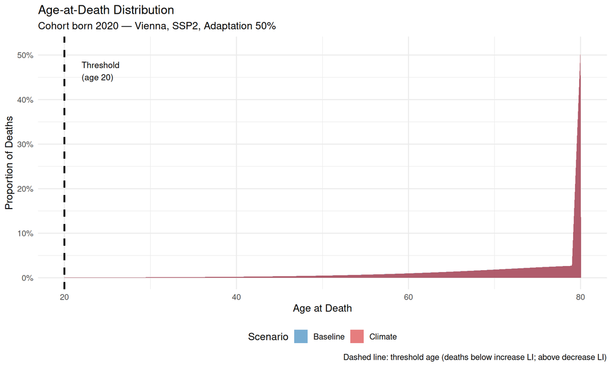

```r
# Combine distributions for plotting
dist_combined <- rbind(
  deaths_base[, .(age, deaths = dx, scenario = "Baseline")],
  deaths_climate[, .(age, deaths = dx, scenario = "Climate")]
)

# Calculate proportions for clean visualization
dist_combined[, prop := deaths / sum(deaths), by = scenario]

ggplot(dist_combined, aes(x = age, y = prop, fill = scenario)) +
  geom_area(alpha = 0.6, position = "identity") +
  geom_vline(xintercept = threshold_age, linetype = "dashed",
             color = "black", linewidth = 1) +
  annotate("text", x = threshold_age + 2, y = max(dist_combined$prop) * 0.9,
           label = sprintf("Threshold\n(age %d)", threshold_age),
           hjust = 0, size = 3.5) +
  scale_fill_manual(
    values = c("Baseline" = "#1f77b4", "Climate" = "#d62728"),
    name = "Scenario"
  ) +
  scale_y_continuous(labels = scales::percent_format()) +
  labs(
    title = "Age-at-Death Distribution",
    subtitle = sprintf("Cohort born %d — %s, SSP%d, Adaptation %.0f%%",
                       cohort_birth_year, city, scenario, adaptation_level * 100),
    x = "Age at Death",
    y = "Proportion of Deaths",
    caption = "Dashed line: threshold age (deaths below increase LI; above decrease LI)"
  ) +
  theme_minimal(base_size = 12) +
  theme(legend.position = "bottom")
```

### 14.4.2 Excess Deaths by Age

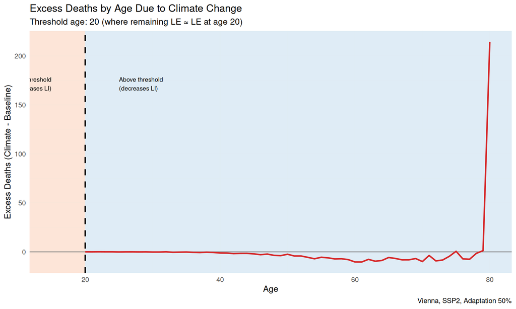

```r
# Highlight threshold region
ggplot(lifetable, aes(x = age, y = excess_deaths)) +
  geom_rect(aes(xmin = -Inf, xmax = threshold_age, ymin = -Inf, ymax = Inf),
            fill = "#fee5d9", alpha = 0.3) +
  geom_rect(aes(xmin = threshold_age, xmax = Inf, ymin = -Inf, ymax = Inf),
            fill = "#deebf7", alpha = 0.3) +
  geom_hline(yintercept = 0, linetype = "solid", color = "gray50") +
  geom_line(color = "#d62728", linewidth = 1) +
  geom_vline(xintercept = threshold_age, linetype = "dashed",
             color = "black", linewidth = 1) +
  annotate("text", x = threshold_age - 5, y = max(lifetable$excess_deaths) * 0.8,
           label = "Below threshold\n(increases LI)", hjust = 1, size = 3) +
  annotate("text", x = threshold_age + 5, y = max(lifetable$excess_deaths) * 0.8,
           label = "Above threshold\n(decreases LI)", hjust = 0, size = 3) +
  scale_y_continuous(labels = scales::comma_format()) +
  labs(
    title = "Excess Deaths by Age Due to Climate Change",
    subtitle = sprintf("Threshold age: %d (where remaining LE ≈ LE at age %d)",
                       threshold_age, cohort_start_age),
    x = "Age",
    y = "Excess Deaths (Climate - Baseline)",
    caption = sprintf("%s, SSP%d, Adaptation %.0f%%",
                      city, scenario, adaptation_level * 100)
  ) +
  theme_minimal(base_size = 12)
```

**Interpretation**: This plot shows the **age pattern** of climate impacts, revealing whether climate predominantly affects “younger old” or “older old” populations.

### 14.4.3 Lifespan Inequality Metrics Summary

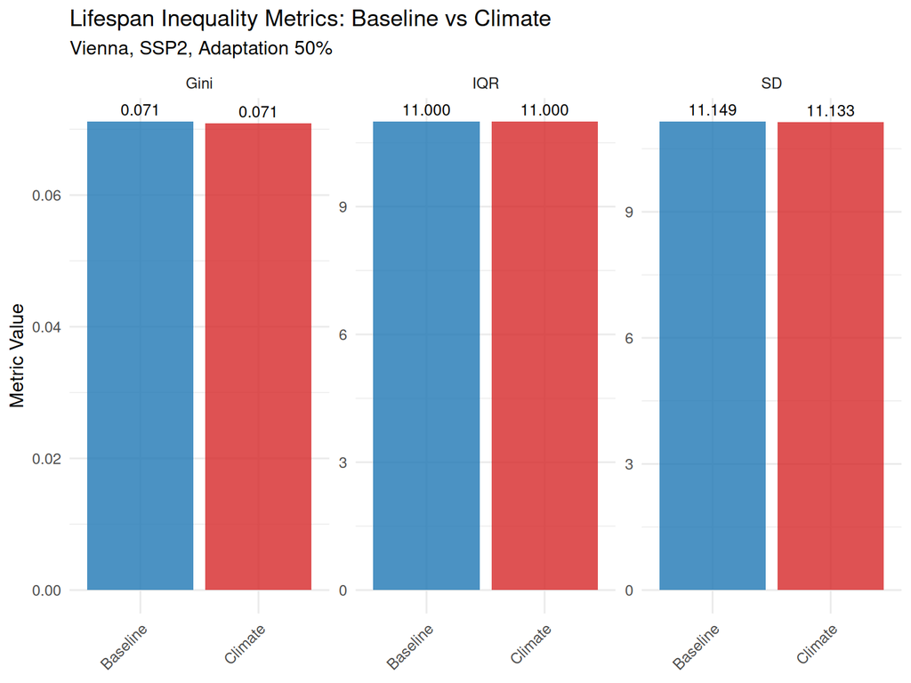

```r
# Create summary data frame
li_metrics <- data.table(
  Metric = c("Gini", "Gini", "SD", "SD", "IQR", "IQR"),
  Scenario = rep(c("Baseline", "Climate"), 3),
  Value = c(gini_base, gini_climate,
            sd_base, sd_climate,
            iqr_base$iqr, iqr_climate$iqr)
)

# Normalize for visualization (within each metric)
li_metrics[, Value_norm := Value / Value[1], by = Metric]

ggplot(li_metrics, aes(x = Scenario, y = Value, fill = Scenario)) +
  geom_col(alpha = 0.8) +
  geom_text(aes(label = sprintf("%.3f", Value)),
            vjust = -0.5, size = 3.5) +
  facet_wrap(~ Metric, scales = "free_y", nrow = 1) +
  scale_fill_manual(
    values = c("Baseline" = "#1f77b4", "Climate" = "#d62728")
  ) +
  labs(
    title = "Lifespan Inequality Metrics: Baseline vs Climate",
    subtitle = sprintf("%s, SSP%d, Adaptation %.0f%%",
                       city, scenario, adaptation_level * 100),
    y = "Metric Value",
    x = NULL
  ) +
  theme_minimal(base_size = 12) +
  theme(legend.position = "none",
        axis.text.x = element_text(angle = 45, hjust = 1))
```

## 14.5 Summary Table

```r
# Create comprehensive summary
li_summary <- data.table(
  Metric = c("Life Expectancy at 20", "Gini Coefficient",
             "SD of Age at Death", "IQR of Age at Death",
             "Threshold Age", "Excess Deaths Below Threshold",
             "Excess Deaths Above Threshold"),
  Baseline = c(
    sprintf("%.2f years", e20_base),
    sprintf("%.4f", gini_base),
    sprintf("%.2f years", sd_base),
    sprintf("%.1f years", iqr_base$iqr),
    sprintf("%d years", threshold_age),
    "—",
    "—"
  ),
  Climate = c(
    sprintf("%.2f years", e20_climate),
    sprintf("%.4f", gini_climate),
    sprintf("%.2f years", sd_climate),
    sprintf("%.1f years", iqr_climate$iqr),
    "—",
    sprintf("%.0f (%.1f%%)", excess_summary$excess_below, pct_below),
    sprintf("%.0f (%.1f%%)", excess_summary$excess_above, pct_above)
  ),
  Change = c(
    sprintf("%.2f years (%.2f%%)", delta_e20, pct_delta_e20),
    sprintf("%.4f (%.2f%%)", delta_gini, pct_change_gini),
    sprintf("%.2f years (%.2f%%)", delta_sd, pct_change_sd),
    sprintf("%.1f years", delta_iqr),
    "—",
    "—",
    "—"
  )
)

cat("\n=== Lifespan Inequality Summary ===\n")
```

```
##
## === Lifespan Inequality Summary ===
```

```r
print(li_summary)
```

```
##                           Metric    Baseline     Climate               Change
##                           <char>      <char>      <char>               <char>
## 1:         Life Expectancy at 20 62.41 years 62.49 years   0.08 years (0.12%)
## 2:              Gini Coefficient      0.0712      0.0709     -0.0003 (-0.41%)
## 3:            SD of Age at Death 11.15 years 11.13 years -0.02 years (-0.14%)
## 4:           IQR of Age at Death  11.0 years  11.0 years            0.0 years
## 5:                 Threshold Age    20 years           —                    —
## 6: Excess Deaths Below Threshold           —    0 (0.0%)                    —
## 7: Excess Deaths Above Threshold           —  0 (100.0%)                    —
```

## 14.6 Export Lifespan Inequality Results

```r
# Create output directory if needed
if (!dir.exists("results")) dir.create("results", recursive = TRUE)

# Save detailed metrics
li_results <- data.table(
  city = city,
  scenario = sprintf("SSP%d", scenario),
  adaptation = adaptation_level,
  cohort_birth_year = cohort_birth_year,
  # Life expectancy
  e20_baseline = e20_base,
  e20_climate = e20_climate,
  delta_e20 = delta_e20,
  pct_change_e20 = pct_delta_e20,
  # Gini
  gini_baseline = gini_base,
  gini_climate = gini_climate,
  delta_gini = delta_gini,
  pct_change_gini = pct_change_gini,
  # Standard deviation
  sd_baseline = sd_base,
  sd_climate = sd_climate,
  delta_sd = delta_sd,
  pct_change_sd = pct_change_sd,
  # IQR
  iqr_baseline = iqr_base$iqr,
  iqr_climate = iqr_climate$iqr,
  delta_iqr = delta_iqr,
  # Threshold
  threshold_age = threshold_age,
  # Excess deaths classification
  total_excess_deaths = excess_summary$total_excess,
  excess_deaths_below_threshold = excess_summary$excess_below,
  excess_deaths_above_threshold = excess_summary$excess_above,
  pct_excess_below = pct_below,
  pct_excess_above = pct_above
)

# Save
li_path <- sprintf("results/lifespan_inequality_%s_ssp%d_cohort%d.csv",
                   tolower(gsub(" ", "_", city)),
                   scenario,
                   cohort_birth_year)

fwrite(li_results, li_path)
cat(sprintf("\nSaved: %s\n", li_path))
```

```
##
## Saved: results/lifespan_inequality_vienna_ssp2_cohort2020.csv
```

```r
# Also save age-specific excess deaths for detailed analysis
excess_by_age <- lifetable[, .(
  age, year,
  dx_baseline = dx_base,
  dx_climate = dx_climate,
  excess_deaths,
  below_threshold,
  multiplier
)]

excess_path <- sprintf("results/excess_deaths_by_age_%s_ssp%d.csv",
                       tolower(gsub(" ", "_", city)),
                       scenario)

fwrite(excess_by_age, excess_path)
cat(sprintf("Saved: %s\n", excess_path))
```

```
## Saved: results/excess_deaths_by_age_vienna_ssp2.csv
```

## 14.7 Key Findings Interpretation

```r
cat("\n=== KEY FINDINGS ===\n\n")
```

```
##
## === KEY FINDINGS ===
```

```r
cat(sprintf("For the cohort born in %d in %s under SSP%d:\n\n",
            cohort_birth_year, city, scenario))
```

```
## For the cohort born in 2020 in Vienna under SSP2:
```

```r
# Life expectancy
cat("1. LIFE EXPECTANCY\n")
```

```
## 1. LIFE EXPECTANCY
```

```r
if (delta_e20 < 0) {
  cat(sprintf("   → Climate change REDUCES life expectancy by %.2f years (%.2f%%)\n",
              abs(delta_e20), abs(pct_delta_e20)))
  cat(sprintf("   → Equivalent to %.1f months lost\n", abs(delta_e20) * 12))
} else {
  cat(sprintf("   → Climate change INCREASES life expectancy by %.2f years (%.2f%%)\n",
              delta_e20, pct_delta_e20))
  cat("   → (Likely due to reduced cold-related mortality)\n")
}
```

```
##    → Climate change INCREASES life expectancy by 0.08 years (0.12%)
##    → (Likely due to reduced cold-related mortality)
```

```r
# Lifespan inequality
cat("\n2. LIFESPAN INEQUALITY\n")
```

```
##
## 2. LIFESPAN INEQUALITY
```

```r
if (delta_gini > 0) {
  cat(sprintf("   → Climate change INCREASES inequality (Gini: +%.4f, +%.1f%%)\n",
              delta_gini, pct_change_gini))
  cat("   → Ages at death become MORE unequally distributed\n")
} else {
  cat(sprintf("   → Climate change DECREASES inequality (Gini: %.4f, %.1f%%)\n",
              delta_gini, pct_change_gini))
  cat("   → Ages at death become MORE equally distributed\n")
}
```

```
##    → Climate change DECREASES inequality (Gini: -0.0003, -0.4%)
##    → Ages at death become MORE equally distributed
```

```r
cat(sprintf("   → Standard deviation changes by %.2f years\n", delta_sd))
```

```
##    → Standard deviation changes by -0.02 years
```

```r
cat(sprintf("   → IQR changes by %.1f years\n", delta_iqr))
```

```
##    → IQR changes by 0.0 years
```

```r
# Mechanism
cat("\n3. MECHANISM\n")
```

```
##
## 3. MECHANISM
```

```r
cat(sprintf("   → Threshold age: %d years\n", threshold_age))
```

```
##    → Threshold age: 20 years
```

```r
cat(sprintf("   → %.1f%% of excess deaths occur BELOW threshold\n", pct_below))
```

```
##    → 0.0% of excess deaths occur BELOW threshold
```

```r
cat(sprintf("   → %.1f%% of excess deaths occur ABOVE threshold\n", pct_above))
```

```
##    → 100.0% of excess deaths occur ABOVE threshold
```

```r
if (pct_below > 60) {
  cat("   → Climate predominantly kills 'younger old' people\n")
  cat("   → This is the PRIMARY driver of increased inequality\n")
} else if (pct_above > 60) {
  cat("   → Climate predominantly kills 'older old' people\n")
  cat("   → This compresses the age-at-death distribution\n")
} else {
  cat("   → Climate impacts are distributed across ages\n")
  cat("   → Net inequality effect depends on relative magnitudes\n")
}
```

```
##    → Climate predominantly kills 'older old' people
##    → This compresses the age-at-death distribution
```

```r
# Policy implication
cat("\n4. POLICY IMPLICATION\n")
```

```
##
## 4. POLICY IMPLICATION
```

```r
if (delta_gini > 0) {
  cat("   → Without adaptation, climate change increases health inequity\n")
  cat("   → Priority: protect vulnerable 'younger old' populations\n")
} else {
  cat("   → Climate has a compression effect on lifespans\n")
  cat("   → But mean LE still affected—focus on absolute longevity\n")
}
```

```
##    → Climate has a compression effect on lifespans
##    → But mean LE still affected—focus on absolute longevity
```

```r
cat(sprintf("\n   → With %.0f%% adaptation by 2100, these impacts are partially mitigated\n",
            adaptation_level * 100))
```

```
##
##    → With 50% adaptation by 2100, these impacts are partially mitigated
```

## Next Steps for Full Pipeline

1. **Multiple scenarios**: Run for all SSPs (1, 2, 3, 5) and adaptation levels (0%, 25%, 50%, 75%, 100%)
2. **Multiple cities**: Extend to 10-20 European cities (Vienna, Madrid, Stockholm, Athens, etc.)
3. **Geographic decomposition**: Compute within-city vs between-city inequality components
4. **Temporal trends**: Track how LI evolves year-by-year (not just single cohort)
5. **Heat vs cold decomposition**: Separate LI impacts of heat vs cold mortality

This single-city demo provides the **methodological foundation** for the full multi-scenario, multi-city analysis in Simon’s Paper 1.